# Project Python Foundations: FoodHub Data Analysis

#### Observations:

- American food is the most popular cuisine type on the weekends.
- American food is the most popular cuisine type during the week as well.
- Japanese food is the second most popular cuisine on weekends.
- There were 415 orders of American food on the weekend out of the 1351 total orders.
- Most popular cuisine type doesn't change between weekdays and weekends.
- American cuisine received 80 more orders than Japanese cuisine, This shows a noticeable preference for American food on weekends.

### **Question 9**: What percentage of the orders cost more than 20 dollars? [2 marks]

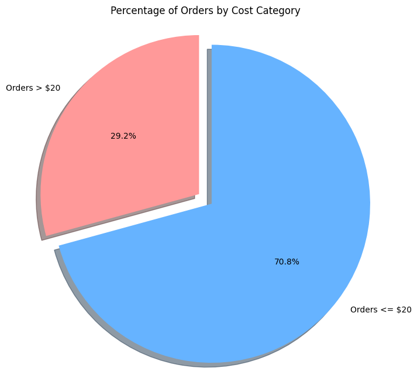

```python
orders_over_20 = (df['cost_of_the_order'] > 20).sum()
orders_20_or_less = (df['cost_of_the_order'] <= 20).sum()

labels = ['Orders > $20', 'Orders <= $20']
sizes = [orders_over_20, orders_20_or_less]
colors = ['#ff9999','#66b3ff']
explode = (0.1, 0)  # explode 1st slice

plt.figure(figsize=(8, 8))
plt.pie(sizes, explode=explode, labels=labels, colors=colors, autopct='%1.1f%%',
        shadow=True, startangle=90)
plt.axis('equal')  # Equal aspect ratio ensures that pie is drawn as a circle.
plt.title('Percentage of Orders by Cost Category')
plt.show()
```

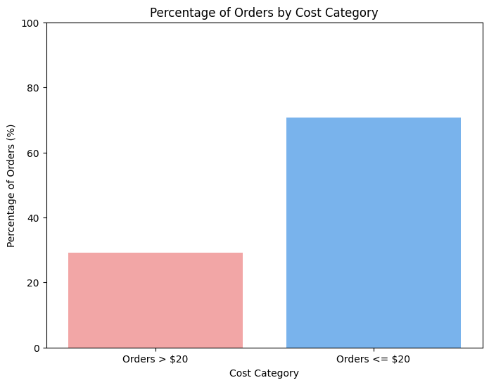

```python
plt.figure(figsize=(8, 6))
sns.barplot(x=labels, y=[s / sum(sizes) * 100 for s in sizes], palette=colors, hue=labels, legend=False)
plt.title('Percentage of Orders by Cost Category')
plt.xlabel('Cost Category')
plt.ylabel('Percentage of Orders (%)')
plt.ylim(0, 100) # Ensure y-axis goes from 0 to 100
plt.show()
```

```python
orders_over_20 = (df['cost_of_the_order'] > 20).sum()
total_orders = df['cost_of_the_order'].count()
percentage_over_20 = (orders_over_20 / total_orders) * 100

print("Orders over $20:", orders_over_20)
print("Total orders:", total_orders)
print(f"Percentage over $20: {percentage_over_20:.2f}%")
```

```
Orders over $20: 555
Total orders: 1898
Percentage over $20: 29.24%
```

#### Observations:

- Nearly 30% of orders cost more than $20.
- 555 out of 1898 orders cost more than $20.
- The majority of orders cost $20 or less which means that prices are fairly reasonable.

### **Question 10**: What is the mean order delivery time? [1 mark]

```python
mean_delivery_time = df['delivery_time'].mean()

print(f"Mean delivery time: {mean_delivery_time:.2f} minutes")
```

```
Mean delivery time: 24.16 minutes
```

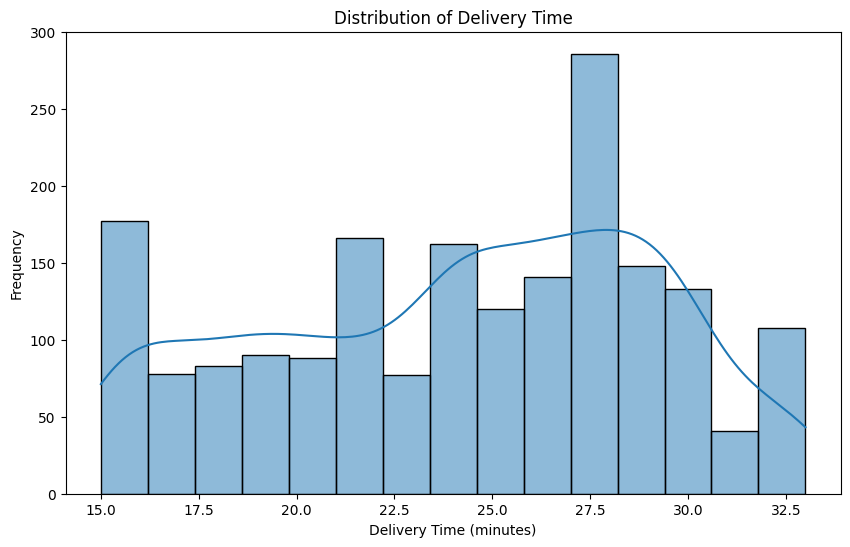

```python
plt.figure(figsize=(10, 6))
sns.histplot(df['delivery_time'], bins=15, kde=True)
plt.title('Distribution of Delivery Time')
plt.xlabel('Delivery Time (minutes)')
plt.ylabel('Frequency')
plt.show()
```

```python
longest_delivery_time = df['delivery_time'].max()

print(f"Longest delivery time: {longest_delivery_time} minutes")
```

```
Longest delivery time: 33.0 minutes
```

```python
shortest_delivery_time = df['delivery_time'].min()

print(f"Shortest delivery time: {shortest_delivery_time} minutes")
```

```
Shortest delivery time: 15.0 minutes
```

### **Question 11:** The company has decided to give 20% discount vouchers to the top 5 most frequent customers. Find the IDs of these customers and the number of orders they placed. [1 mark]

```python
top_5_customers = df['customer_id'].value_counts().head(5)
print("Top 5 most frequent customers:\n", top_5_customers)
```

```
Top 5 most frequent customers:
 customer_id
52832.0     13
47440.0     10
83287.0      9
250494.0     8
259341.0     7
Name: count, dtype: int64
```

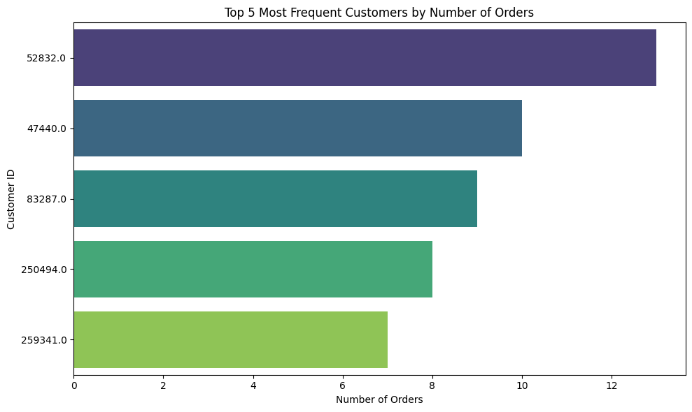

```python
top_5_customers = df['customer_id'].value_counts().head(5)
plt.figure(figsize=(10, 6))
sns.barplot(x=top_5_customers.values, y=top_5_customers.index.astype(str), palette='viridis', hue=top_5_customers.index.astype(str), legend=False)
plt.title('Top 5 Most Frequent Customers by Number of Orders')
plt.xlabel('Number of Orders')
plt.ylabel('Customer ID')
plt.tight_layout()
plt.show()
```

#### Observations:

- The customer with the most orders has the customer ID 52832. They have ordered 13 times.
- There is a clear difference between the most frequent customer and the other customers. The top customer places 3 more orders than the second-highest customer.

### **Question 12**: Perform a multivariate analysis to explore relationships between the important variables in the dataset. (It is a good idea to explore relations between numerical variables as well as relations between numerical and categorical variables) [10 marks]

### Relationship between Cost of the Order and Delivery Time by Day of the Week

```python
df.head()
```

|  | Unnamed: 0 | customer_id | restaurant_name | cuisine_type | cost_of_the_order | day_of_the_week | rating | food_preparation_time | delivery_time | total_time |
| --- | --- | --- | --- | --- | --- | --- | --- | --- | --- | --- |
| 0 | order_id | 337525.0 | Hangawi | Korean | 30.75 | Weekend | Not given | 25.0 | 20.0 | 45.0 |
| 1 | 1477147 | 358141.0 | Blue Ribbon Sushi Izakaya | Japanese | 12.08 | Weekend | Not given | 25.0 | 23.0 | 48.0 |
| 2 | 1477685 | 66393.0 | Cafe Habana | Mexican | 12.23 | Weekday | 5 | 23.0 | 28.0 | 51.0 |
| 3 | 1477070 | 106968.0 | Blue Ribbon Fried Chicken | American | 29.20 | Weekend | 3 | 25.0 | 15.0 | 40.0 |
| 4 | 1477334 | 76942.0 | Dirty Bird to Go | American | 11.59 | Weekday | 4 | 25.0 | 24.0 | 49.0 |